# Fiscal Health Dimensions, Tax Year 2023

Dimension discovery on the winsorized + normalized ratio frame

## Purpose

`fiscal-health-index-2023.Rmd` found two dimensions: *Reserves & Solvency* and *Operating Performance*. That result depended on screening out most of the candidate ratios. The AA/NH/PI study (Urban Institute) found four: growth potential, leverage, solvency, and organizational slack. `vignette("variance-preserving-normalization")` showed that the difference comes mostly from **which ratios are measured, and how**, not from the transformation. It then built a measurement model that keeps every candidate ratio defined for every organization:

- bounded or symmetric reformulations where the direction of an undefined case is known (negative net assets, a non-positive growth base);
- stochastic conditional imputation where it is not (no current liabilities, unreported functional expenses);
- 1st/99th percentile winsorizing, then asinh for ratios that stay skewed, then a z-score.

This document reruns dimension discovery on that frame for all 2023 full-990 filers, and records how each decision was made.

**Key ideas**

- **Measurement model first:** decide how each ratio is defined, filled in, and transformed *before* factoring. Those choices determine which correlations the model can find.
- **Parallel analysis and MAP:** two rules for how many dimensions to keep. Parallel analysis keeps components that beat random data; MAP stops when another component no longer removes shared (partial) correlation.
- **Oblique rotation (oblimin):** lets dimensions correlate, which is realistic for financial constructs. The component correlation matrix shows how much they overlap.
- **Tucker congruence:** similarity of two loading patterns. At 0.95 or above, the dimension has effectively reproduced.
- **Context dimension:** a stable empirical dimension with no healthy direction. Use it to describe or stratify organizations, not in a health score.

```r
library(dplyr)
library(knitr)
library(psych)
library(corrplot)
if (file.exists(file.path(params$pkg_dir, "DESCRIPTION"))) {
  pkgload::load_all(params$pkg_dir, quiet = TRUE)
} else {
  library(fiscal)
}
source("build-ratio-frame.R")   # measurement model from the vignette
set.seed(params$seed)
fmt <- function(x, d = 2) format(round(x, d), nsmall = d, big.mark = ",")
```

## 1. Build the ratio frame

```r
# Cached by fiscal-health-index-2023.Rmd (efile-2023.rds) or data-raw/create-dat10k.R
# (efile-2023-bmf-dedup.rds); either deduplicated 2023 extract works.
cache_file <- file.path(params$data_dir, c("efile-2023.rds", "efile-2023-bmf-dedup.rds"))
cache_file <- cache_file[file.exists(cache_file)][1]
if (is.na(cache_file)) stop("No cached 2023 e-file extract; render fiscal-health-index-2023.Rmd first.")
efile <- readRDS(cache_file)

# 2022 header, summary, and balance-sheet tables: used in Section 6 to fill
# prior-year revenue the 2023 return leaves blank and to validate growth rates.
prior_file <- file.path(params$data_dir, "efile-2022-p01p10-dedup.rds")
if (file.exists(prior_file)) {
  prior <- readRDS(prior_file)
} else {
  prior <- retrieve_efile_data(year = 2022, tables = c("P00", "P01", "P10"),
                               include_bmf = FALSE,
                               path = file.path(params$data_dir, "efdata"), verbose = FALSE)
  prior <- deduplicate(prior, verbose = FALSE)
  saveRDS(prior, prior_file)
}
prior <- as.data.frame(prior)[, intersect(c("EIN2", "F9_01_REV_TOT_CY", "F9_10_ASSET_TOT_EOY",
                                  "F9_01_NAFB_ASSET_TOT_EOY"), names(prior))]

# growth = TRUE appends rev_growth and asset_growth; every other ratio is
# identical to the frame built without them.
built <- build_ratio_frame(efile, seed = params$seed, growth = TRUE, prior = prior)
rm(efile); invisible(gc())

frame <- built$frame
growth_vars <- c("rev_growth", "asset_growth")
# Program share = 1 - admin share - fundraising share, so it is left out to
# avoid building a closure component into the matrix. Growth measures are held
# out of Sections 2-5 and tested in Section 6.
candidates <- setdiff(names(frame), c("prog_exp", growth_vars))
X <- as.data.frame(lapply(frame[candidates], winsor_normalize))

data.frame(organizations = format(nrow(X), big.mark = ","),
           candidate_ratios = length(candidates))
```

| organizations | candidate_ratios |
| --- | --- |
| 321,612 | 15 |

```r
kable(data.frame(ratio = names(built$imputed_share),
                 share_imputed = round(built$imputed_share, 3))[built$imputed_share > 0, ],
      row.names = FALSE, caption = "Ratios with imputed values")
```

Ratios with imputed values

| ratio | share_imputed |
| --- | --- |
| current | 0.424 |
| cash_assets | 0.015 |
| return_assets | 0.015 |
| prog_exp | 0.106 |
| admin_exp | 0.106 |
| fundr_exp | 0.106 |
| rev_growth | 0.017 |

## 2. Diagnostics and triage

```r
diagnostics <- fiscal_diagnostics(X)
cat("Overall KMO:", fmt(diagnostics$kmo$MSA, 3), "\n")
```

```
## Overall KMO: 0.639
```

```r
triage_auto <- fiscal_triage(diagnostics)
kable(triage_auto$decisions[, c("variable", "kmo_msa", "communality", "mean_abs_cor",
                                "max_abs_cor", "redundant_with", "decision")],
      digits = 3, row.names = FALSE)
```

| variable | kmo_msa | communality | mean_abs_cor | max_abs_cor | redundant_with | decision |
| --- | --- | --- | --- | --- | --- | --- |
| current | 0.899 | 0.348 | 0.246 | 0.519 |  | retain |
| months_cash | 0.569 | 0.410 | 0.252 | 0.580 |  | retain |
| liquid_months | 0.669 | 0.589 | 0.283 | 0.580 |  | retain |
| cash_assets | 0.441 | 0.328 | 0.179 | 0.512 |  | retain |
| debt_assets | 0.682 | 0.780 | 0.287 | 0.952 | debt_una | retain |
| debt_una | 0.651 | 0.860 | 0.284 | 0.952 | debt_assets | redundant |
| payables_una | 0.888 | 0.512 | 0.248 | 0.723 |  | retain |
| surplus_margin | 0.588 | 0.470 | 0.191 | 0.569 |  | retain |
| return_assets | 0.665 | 0.762 | 0.176 | 0.752 |  | retain |
| na_growth | 0.675 | 0.597 | 0.163 | 0.752 |  | retain |
| self_suff | 0.749 | 0.055 | 0.105 | 0.212 |  | standalone |
| admin_exp | 0.789 | 0.024 | 0.049 | 0.114 |  | standalone |
| fundr_exp | 0.430 | 0.001 | 0.042 | 0.212 |  | noise |
| land_assets | 0.470 | 0.160 | 0.149 | 0.512 |  | standalone |
| assets_rev | 0.461 | 1.010 | 0.184 | 0.539 |  | retain |

The automatic triage flags four things:

- **`debt_una` is redundant with `debt_assets`** (r = 0.95). Once negative unrestricted net assets are placed at the worst end, leverage on unrestricted equity and debt-to-assets rank organizations almost identically. Keeping both would double-weight one idea.
- **`self_suff`, `admin_exp`, and `fundr_exp`** share almost no variance with anything else (communality ≤ 0.05).
- **`land_assets` is marked standalone** because of its low communality in the preliminary screen.
- **Asset-composition ratios (`cash_assets`, `land_assets`, `assets_rev`)** have individual KMO just below 0.50.

The preliminary communality screen fits only 3 factors. Section 3 shows that a fourth component is defined by `land_assets` and `cash_assets`. So a three-factor communality is not a fair test of whether `land_assets` shares variance, and we override it.

```r
triage <- fiscal_triage(diagnostics, overrides = c(land_assets = "retain"))
kable(triage$decisions[, c("variable", "decision", "overridden", "reason")], row.names = FALSE)
```

| variable | decision | overridden | reason |
| --- | --- | --- | --- |
| current | retain | FALSE | Eligible for multivariate dimension modeling. |
| months_cash | retain | FALSE | Eligible for multivariate dimension modeling. |
| liquid_months | retain | FALSE | Eligible for multivariate dimension modeling. |
| cash_assets | retain | FALSE | Eligible for multivariate dimension modeling. |
| debt_assets | retain | FALSE | Eligible for multivariate dimension modeling. |
| debt_una | redundant | FALSE | Provisional drop from a highly correlated redundancy group. |
| payables_una | retain | FALSE | Eligible for multivariate dimension modeling. |
| surplus_margin | retain | FALSE | Eligible for multivariate dimension modeling. |
| return_assets | retain | FALSE | Eligible for multivariate dimension modeling. |
| na_growth | retain | FALSE | Eligible for multivariate dimension modeling. |
| self_suff | standalone | FALSE | Low communality; retain as a possible standalone indicator rather than forcing it into a shared dimension. |
| admin_exp | standalone | FALSE | Low communality; retain as a possible standalone indicator rather than forcing it into a shared dimension. |
| fundr_exp | noise | FALSE | Low KMO, low communality, and weak overall connectedness. |
| land_assets | retain | TRUE | User override: retain. |
| assets_rev | retain | FALSE | Eligible for multivariate dimension modeling. |

```r
retained <- triage$selected_for_dimensions
retained
```

```
##  [1] "current"        "months_cash"    "liquid_months"  "cash_assets"    "debt_assets"    "payables_una"
##  [7] "surplus_margin" "return_assets"  "na_growth"      "land_assets"    "assets_rev"
```

> **Decision A: Drop `debt_una` as redundant and keep `debt_assets`.** Debt-to-assets needs no net-asset-class data and is the more widely used measure.

> **Decision B: Keep `land_assets` for dimension estimation**, overriding the three-factor communality screen (see Section 3).

> **Decision C: Keep `self_suff`, `admin_exp`, and `fundr_exp` out of dimension estimation as standalone measures.** They describe revenue model and expense allocation, and they carry little shared variance with financial condition. Section 3.3 shows what happens if they are forced in.

## 3. How many dimensions?

### 3.1 Retention criteria

```r
R <- cor(X[retained])
eig <- eigen(R, only.values = TRUE)$values
invisible(capture.output(
  pa <- fa.parallel(R, n.obs = nrow(X), fa = "both", plot = FALSE, n.iter = 50)))
invisible(capture.output(v <- vss(R, n = 8, n.obs = nrow(X), plot = FALSE)))
kable(data.frame(component = seq_along(eig), eigenvalue = eig,
                 pca_random = pa$pc.sim[seq_along(eig)],
                 share = eig / sum(eig), cumulative = cumsum(eig) / sum(eig)),
      digits = 3, row.names = FALSE)
```

| component | eigenvalue | pca_random | share | cumulative |
| --- | --- | --- | --- | --- |
| 1 | 3.427 | 1.009 | 0.312 | 0.312 |
| 2 | 1.938 | 1.007 | 0.176 | 0.488 |
| 3 | 1.819 | 1.005 | 0.165 | 0.653 |
| 4 | 1.089 | 1.003 | 0.099 | 0.752 |
| 5 | 0.818 | 1.002 | 0.074 | 0.826 |
| 6 | 0.595 | 1.000 | 0.054 | 0.881 |
| 7 | 0.428 | 0.999 | 0.039 | 0.920 |
| 8 | 0.313 | 0.997 | 0.028 | 0.948 |
| 9 | 0.239 | 0.995 | 0.022 | 0.970 |
| 10 | 0.196 | 0.993 | 0.018 | 0.988 |
| 11 | 0.137 | 0.990 | 0.012 | 1.000 |

```r
data.frame(criterion = c("Parallel analysis (PCA)", "Parallel analysis (FA)",
                         "Velicer MAP minimum", "Kaiser (eigenvalue > 1)"),
           dimensions = c(pa$ncomp, pa$nfact, which.min(v$map), sum(eig > 1)))
```

| criterion | dimensions |
| --- | --- |
| Parallel analysis (PCA) | 4 |
| Parallel analysis (FA) | 5 |
| Velicer MAP minimum | 1 |
| Kaiser (eigenvalue > 1) | 4 |

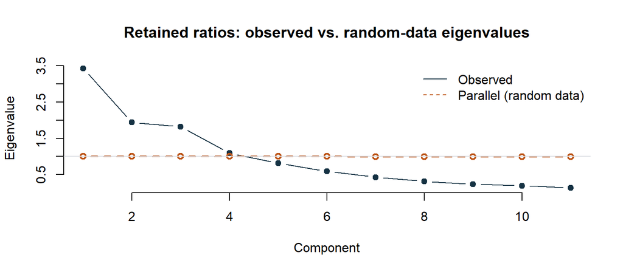

```r
plot(eig, type = "b", pch = 19, col = "#153243", bty = "n", xlab = "Component",
     ylab = "Eigenvalue", main = "Retained ratios: observed vs. random-data eigenvalues")
lines(pa$pc.sim[seq_along(eig)], type = "b", lty = 2, lwd = 2, col = "#bd5416")
abline(h = 1, col = "#dcdfe4")
legend("topright", c("Observed", "Parallel (random data)"), lty = c(1, 2),
       col = c("#153243", "#bd5416"), bty = "n")
```

### 3.2 Solutions with 3, 4, and 5 components

All solutions use PCA with an oblique (oblimin) rotation, so dimensions are allowed to correlate. Loadings below 0.30 are blanked.

```r
show_solution <- function(k) {
  m <- principal(R, nfactors = k, rotate = "oblimin", n.obs = nrow(X))
  L <- unclass(m$loadings)
  L[abs(L) < 0.30] <- NA
  colnames(L) <- paste0("k", k, "_C", seq_len(k))
  L
}
kable(do.call(cbind, lapply(3:5, show_solution)), digits = 2)
```

|  | k3_C1 | k3_C2 | k3_C3 | k4_C1 | k4_C2 | k4_C3 | k4_C4 | k5_C1 | k5_C2 | k5_C3 | k5_C4 | k5_C5 |
| --- | --- | --- | --- | --- | --- | --- | --- | --- | --- | --- | --- | --- |
| current | 0.67 |  |  |  | 0.41 | -0.40 |  |  | -0.34 |  | 0.76 |  |
| months_cash | 0.70 |  |  |  | 0.85 |  |  |  |  | 0.32 | 0.82 |  |
| liquid_months | 0.82 |  |  |  | 0.76 |  |  |  |  | 0.71 |  | -0.41 |
| cash_assets |  |  | -0.87 |  |  |  | 0.88 |  |  | -0.63 | 0.46 | -0.41 |
| debt_assets | -0.65 |  | 0.35 |  |  | 0.88 |  |  | 0.89 |  |  |  |
| payables_una | -0.66 |  |  |  |  | 0.92 |  |  | 0.92 |  |  |  |
| surplus_margin |  | 0.77 |  | 0.77 |  |  |  | 0.76 |  |  |  |  |
| return_assets |  | 0.91 |  | 0.91 |  |  |  | 0.91 |  |  |  |  |
| na_growth |  | 0.87 |  | 0.88 |  |  |  | 0.88 |  |  |  |  |
| land_assets |  |  | 0.69 |  |  |  | -0.81 |  |  |  |  | 0.97 |
| assets_rev | 0.64 |  | 0.65 |  | 0.77 |  | -0.47 |  |  | 0.86 |  |  |

```r
dimensions <- fiscal_dimensions(X, triage = triage, method = "pca", nfactors = NULL,
                                seed = params$seed, parallel_iter = 50)
```

```
## Parallel analysis suggests that the number of factors =  NA  and the number of components =  4
```

```r
dimensions
```

```
## Fiscal dimension discovery
##   Method: PCA
##   Dimensions: 4 ( parallel )
##   Multi-indicator dimensions: 4
##   Cross-loading indicators: 2
##   Unassigned indicators: 0
```

```r
kable(dimensions$assignments, digits = 2, row.names = FALSE)
```

| variable | primary_dimension | primary_loading | primary_abs_loading | secondary_abs_loading | cross_loading | status |
| --- | --- | --- | --- | --- | --- | --- |
| current | Dimension2 | 0.41 | 0.41 | 0.40 | TRUE | cross_loading |
| months_cash | Dimension2 | 0.85 | 0.85 | 0.23 | FALSE | assigned |
| liquid_months | Dimension2 | 0.76 | 0.76 | 0.22 | FALSE | assigned |
| cash_assets | Dimension4 | 0.88 | 0.88 | 0.09 | FALSE | assigned |
| debt_assets | Dimension3 | 0.88 | 0.88 | 0.07 | FALSE | assigned |
| payables_una | Dimension3 | 0.92 | 0.92 | 0.06 | FALSE | assigned |
| surplus_margin | Dimension1 | 0.77 | 0.77 | 0.18 | FALSE | assigned |
| return_assets | Dimension1 | 0.91 | 0.91 | 0.07 | FALSE | assigned |
| na_growth | Dimension1 | 0.88 | 0.88 | 0.05 | FALSE | assigned |
| land_assets | Dimension4 | -0.81 | 0.81 | 0.16 | FALSE | assigned |
| assets_rev | Dimension2 | 0.77 | 0.77 | 0.47 | TRUE | cross_loading |

```r
kable(dimensions$clusters, row.names = FALSE)
```

| dimension | n_indicators | indicators | candidate_type |
| --- | --- | --- | --- |
| Dimension1 | 3 | surplus_margin; return_assets; na_growth | multi_indicator |
| Dimension2 | 4 | current; months_cash; liquid_months; assets_rev | multi_indicator |
| Dimension3 | 2 | debt_assets; payables_una | multi_indicator |
| Dimension4 | 2 | cash_assets; land_assets | multi_indicator |

```r
efa <- fa(R, nfactors = dimensions$nfactors, rotate = "oblimin", fm = "minres", n.obs = nrow(X))
L_efa <- unclass(efa$loadings); L_efa[abs(L_efa) < 0.30] <- NA
kable(L_efa, digits = 2, caption = "EFA (minres, oblimin): same number of factors")
```

EFA (minres, oblimin): same number of factors

|  | MR1 | MR3 | MR2 | MR4 |
| --- | --- | --- | --- | --- |
| current |  | 0.36 | -0.33 |  |
| months_cash |  | 0.89 |  |  |
| liquid_months |  | 0.59 | -0.32 |  |
| cash_assets |  |  |  | 0.99 |
| debt_assets |  |  | 0.87 |  |
| payables_una |  |  | 0.78 |  |
| surplus_margin | 0.61 |  |  |  |
| return_assets | 0.92 |  |  |  |
| na_growth | 0.79 |  |  |  |
| land_assets |  |  |  | -0.46 |
| assets_rev |  | 0.64 |  | -0.50 |

```r
kable(round(efa$Phi, 2), caption = "EFA factor correlations")
```

EFA factor correlations

|  | MR1 | MR3 | MR2 | MR4 |
| --- | --- | --- | --- | --- |
| MR1 | 1.00 | 0.15 | -0.18 | 0.12 |
| MR3 | 0.15 | 1.00 | -0.35 | -0.02 |
| MR2 | -0.18 | -0.35 | 1.00 | -0.15 |
| MR4 | 0.12 | -0.02 | -0.15 | 1.00 |

> **Decision D: Retain four dimensions.**

> *Why:*
> - **Criteria disagree, as they usually do.** PCA parallel analysis and the Kaiser rule keep 4 and 4; factor-analytic parallel analysis keeps 5. Velicer’s MAP reaches its minimum with 1 component(s). MAP is known to under-extract when each dimension has only two to four indicators, and here it mainly signals that a general factor sits behind the ratios. That is consistent with building a composite, but it is not a reason to collapse distinct constructs.
> - **Three components merge two clusters.** Leverage and liquidity collapse into one bipolar component, even though the four-component solution shows they separate cleanly.
> - **Five components trade one coherent dimension for a finer split.** The liquidity block splits into *short-term liquidity* (current ratio, months of cash) and *accumulated reserves* (liquid months, asset intensity). Asset structure breaks up: land share becomes a near-singleton, and cash share cross-loads on both liquidity components. That split is substantively plausible and worth testing on panel data. At four components, though, every dimension is an interpretable multi-indicator cluster.
> - **Simple structure.** In the four-component solution, every cluster has at least two indicators with primary loadings above 0.75. Only `current` and `assets_rev` cross-load.
> - **EFA agrees.** Common-factor analysis, which ignores unique variance, recovers the same grouping. The current ratio and liquid months take small secondary loadings on leverage.

> If the automated `fiscal_dimensions()` count differs from four, the fit below uses four explicitly. The comparison above is the basis for that choice.

```r
if (dimensions$nfactors != 4) {
  dimensions <- fiscal_dimensions(X, triage = triage, method = "pca", nfactors = 4,
                                  seed = params$seed)
}
kable(dimensions$clusters, row.names = FALSE)
```

| dimension | n_indicators | indicators | candidate_type |
| --- | --- | --- | --- |
| Dimension1 | 3 | surplus_margin; return_assets; na_growth | multi_indicator |
| Dimension2 | 4 | current; months_cash; liquid_months; assets_rev | multi_indicator |
| Dimension3 | 2 | debt_assets; payables_una | multi_indicator |
| Dimension4 | 2 | cash_assets; land_assets | multi_indicator |

### 3.3 What happens if the expense and revenue-model ratios are forced in?

```r
R_all <- cor(X[setdiff(candidates, "debt_una")])
invisible(capture.output(pa_all <- fa.parallel(R_all, n.obs = nrow(X), fa = "both",
                                               plot = FALSE, n.iter = 20)))
for (k in c(5, 6)) {
  m <- principal(R_all, nfactors = k, rotate = "oblimin", n.obs = nrow(X))
  L <- unclass(m$loadings); L[abs(L) < 0.30] <- NA
  print(kable(L, digits = 2, caption = paste(k, "components with all candidate ratios")))
}
```

```
##
##
## Table: 5 components with all candidate ratios
##
## |               |  PC2|  PC1|   PC5|   PC3|   PC4|
## |:--------------|----:|----:|-----:|-----:|-----:|
## |current        |     | 0.41| -0.41|      |      |
## |months_cash    |     | 0.82|      |      |      |
## |liquid_months  |     | 0.75|      |      |      |
## |cash_assets    |     |     |      |  0.88|      |
## |debt_assets    |     |     |  0.82|      |      |
## |payables_una   |     |     |  0.86|      |      |
## |surplus_margin | 0.77|     |      |      |      |
## |return_assets  | 0.91|     |      |      |      |
## |na_growth      | 0.87|     |      |      |      |
## |self_suff      |     |     |      |      |  0.68|
## |admin_exp      |     | 0.43|  0.44|      | -0.31|
## |fundr_exp      |     |     |      |      | -0.79|
## |land_assets    |     |     |      | -0.80|      |
## |assets_rev     |     | 0.73|      | -0.49|      |
##
##
## Table: 6 components with all candidate ratios
##
## |               |  PC2|  PC1|   PC5|   PC3|   PC4|  PC6|
## |:--------------|----:|----:|-----:|-----:|-----:|----:|
## |current        |     | 0.42| -0.40|      |      |     |
## |months_cash    |     | 0.85|      |      |      |     |
## |liquid_months  |     | 0.74|      |      |      |     |
## |cash_assets    |     |     |      |  0.88|      |     |
## |debt_assets    |     |     |  0.88|      |      |     |
## |payables_una   |     |     |  0.93|      |      |     |
## |surplus_margin | 0.76|     |      |      |      |     |
## |return_assets  | 0.91|     |      |      |      |     |
## |na_growth      | 0.87|     |      |      |      |     |
## |self_suff      |     |     |      |      |  0.74|     |
## |admin_exp      |     |     |      |      |      | 0.99|
## |fundr_exp      |     |     |      |      | -0.79|     |
## |land_assets    |     |     |      | -0.80|      |     |
## |assets_rev     |     | 0.78|      | -0.47|      |     |
```

```r
c(parallel_pca = pa_all$ncomp, parallel_fa = pa_all$nfact)
```

```
## parallel_pca  parallel_fa
##            5            6
```

## 4. Stability

A dimension worth naming should reappear:

- in independent halves of the data;
- in organizations of very different size;
- under alternative transformations;
- in a different tax year.

We compare loading matrices with Tucker’s congruence coefficient, matching components across solutions by the best permutation. Values ≥ 0.95 mean the factors are effectively equal; 0.85–0.94 means fair similarity.

```r
perms <- function(n) {
  if (n == 1) return(list(1L))
  out <- list()
  for (i in seq_len(n)) for (p in perms(n - 1)) out[[length(out) + 1]] <- c(i, setdiff(seq_len(n), i)[p])
  out
}
loadings_k4 <- function(df) unclass(principal(df[retained], nfactors = 4, rotate = "oblimin")$loadings)
label_components <- function(L) {
  anchors <- c(leverage = "debt_assets", performance = "return_assets",
               reserves = "months_cash", asset_structure = "land_assets")
  lab <- vapply(seq_len(ncol(L)), function(j) {
    a <- names(anchors)[which.max(abs(L[anchors, j]))]
    a
  }, "")
  colnames(L) <- lab
  L
}
congruence <- function(A, B) {
  C <- abs(psych::factor.congruence(A, B))
  P <- perms(ncol(B))
  best <- P[[which.max(vapply(P, function(p) sum(C[cbind(seq_len(nrow(C)), p)]), 0))]]
  out <- C[cbind(seq_len(nrow(C)), best)]
  names(out) <- colnames(label_components(A))
  out
}
L_ref <- loadings_k4(X)
```

```r
rev_total <- built$components$R
exp_total <- built$components$E
half <- sample(nrow(X), nrow(X) / 2)

X_rank <- as.data.frame(lapply(frame[candidates], rank_normal))
X_w595 <- as.data.frame(lapply(frame[candidates], winsor_normalize, p = 0.05))
X_wins <- as.data.frame(lapply(frame[candidates], function(x) as.numeric(scale(winsor(x)))))

data(dat10k, package = "fiscal")
built21 <- build_ratio_frame(dat10k, seed = params$seed)
X21 <- as.data.frame(lapply(built21$frame[candidates], winsor_normalize))

checks <- list(
  `Random half A vs. half B`          = list(X[half, ], X[-half, ]),
  `Expenses < $500k vs. full sample`  = list(X[exp_total < 5e5, ], X),
  `$500k-$5M vs. full sample`         = list(X[exp_total >= 5e5 & exp_total < 5e6, ], X),
  `>= $5M vs. full sample`            = list(X[exp_total >= 5e6, ], X),
  `Rank-normal vs. winsorized+normalized`      = list(X_rank, X),
  `Winsorize 5/95 vs. 1/99 (normalized)`       = list(X_w595, X),
  `Winsorized only vs. winsorized+normalized`  = list(X_wins, X),
  `2021 sample (dat10k) vs. 2023`              = list(X21, X))

stab <- do.call(rbind, lapply(names(checks), function(nm) {
  A <- loadings_k4(checks[[nm]][[1]])
  B <- if (identical(checks[[nm]][[2]], X)) L_ref else loadings_k4(checks[[nm]][[2]])
  cg <- congruence(B, A)
  data.frame(comparison = nm, n = nrow(checks[[nm]][[1]]), t(round(cg, 3)), check.names = FALSE)
}))
kable(stab, row.names = FALSE, format.args = list(big.mark = ","))
```

| comparison | n | performance | reserves | leverage | asset_structure |
| --- | --- | --- | --- | --- | --- |
| Random half A vs. half B | 160,806 | 1.00 | 1.00 | 1.00 | 1.00 |
| Expenses < $500k vs. full sample | 171,273 | 1.00 | 1.00 | 0.99 | 1.00 |
| $500k-$5M vs. full sample | 111,728 | 1.00 | 0.99 | 0.99 | 1.00 |
| >= $5M vs. full sample | 38,611 | 0.99 | 0.95 | 0.96 | 0.97 |
| Rank-normal vs. winsorized+normalized | 321,612 | 1.00 | 0.99 | 0.99 | 0.99 |
| Winsorize 5/95 vs. 1/99 (normalized) | 321,612 | 1.00 | 1.00 | 1.00 | 1.00 |
| Winsorized only vs. winsorized+normalized | 321,612 | 0.99 | 0.99 | 0.94 | 0.99 |
| 2021 sample (dat10k) vs. 2023 | 6,207 | 1.00 | 1.00 | 1.00 | 1.00 |

```r
by_size <- lapply(list(`< $500k` = exp_total < 5e5, `$500k-$5M` = exp_total >= 5e5 & exp_total < 5e6,
                       `>= $5M` = exp_total >= 5e6),
                  function(rows) label_components(loadings_k4(X[rows, ])))
kable(do.call(cbind, lapply(names(by_size), function(s) {
  L <- by_size[[s]][, c("leverage", "performance", "reserves", "asset_structure")]
  colnames(L) <- paste(s, colnames(L)); L })), digits = 2,
  caption = "Four-component loadings by organization size (total expenses)")
```

Four-component loadings by organization size (total expenses)

|  | < $500k leverage | < $500k performance | < $500k reserves | < $500k asset_structure | $500k-$5M leverage | $500k-$5M performance | $500k-$5M reserves | $500k-$5M asset_structure | >= $5M leverage | >= $5M performance | >= $5M reserves | >= $5M asset_structure |
| --- | --- | --- | --- | --- | --- | --- | --- | --- | --- | --- | --- | --- |
| current | -0.31 | 0.04 | 0.51 | -0.25 | -0.52 | 0.01 | 0.19 | 0.30 | -0.44 | -0.02 | 0.09 | 0.46 |
| months_cash | 0.11 | 0.15 | 0.89 | -0.18 | 0.07 | 0.20 | 0.78 | 0.29 | 0.12 | 0.22 | 0.75 | 0.39 |
| liquid_months | -0.22 | 0.05 | 0.78 | 0.00 | -0.29 | 0.05 | 0.71 | 0.06 | -0.55 | 0.02 | 0.50 | 0.05 |
| cash_assets | 0.01 | -0.02 | -0.03 | -0.92 | -0.09 | -0.02 | -0.14 | 0.87 | 0.00 | 0.02 | -0.18 | 0.87 |
| debt_assets | 0.87 | -0.02 | -0.02 | 0.07 | 0.86 | -0.03 | 0.02 | -0.07 | 0.91 | -0.04 | 0.12 | -0.07 |
| payables_una | 0.90 | 0.00 | 0.03 | -0.06 | 0.91 | 0.00 | 0.00 | 0.08 | 0.90 | -0.04 | -0.04 | 0.06 |
| surplus_margin | 0.03 | 0.75 | 0.20 | -0.03 | 0.03 | 0.80 | 0.12 | 0.05 | 0.01 | 0.82 | 0.09 | 0.02 |
| return_assets | -0.03 | 0.92 | -0.02 | 0.06 | -0.02 | 0.91 | -0.02 | -0.08 | -0.05 | 0.88 | -0.04 | -0.06 |
| na_growth | -0.02 | 0.89 | -0.03 | 0.04 | -0.03 | 0.88 | -0.04 | -0.05 | -0.03 | 0.78 | -0.04 | -0.04 |
| land_assets | 0.07 | 0.11 | -0.16 | 0.80 | -0.04 | 0.09 | -0.20 | -0.80 | 0.12 | 0.16 | -0.23 | -0.66 |
| assets_rev | 0.00 | -0.19 | 0.72 | 0.51 | -0.03 | -0.13 | 0.76 | -0.48 | -0.10 | -0.09 | 0.85 | -0.33 |

**Stability findings.**

- **Near-perfect reproduction** across random halves, across the two smaller size groups, under rank-normal scoring and 5/95 winsorizing, and in the independent 2021 sample. In each case congruence is at least 0.99.
- **Large organizations** (expenses ≥ $5M) still give fair-to-equal congruence (≥ 0.95), but the reserve–leverage boundary shifts. Their current ratio and liquid months load substantially on leverage. For large institutions, liquid unrestricted net assets are largely whatever is left after debt-financed property, so liquidity and leverage move together more.
- **Winsorizing without normalizing** blurs the leverage dimension the most. That matches the vignette’s finding that residual skew weakens correlations among the debt ratios.

## 5. The four dimensions

```r
L_final <- label_components(L_ref)[, c("leverage", "performance", "reserves", "asset_structure")]
kable(L_final, digits = 2, caption = "Four-component oblimin loadings, all 2023 filers")
```

Four-component oblimin loadings, all 2023 filers

|  | leverage | performance | reserves | asset_structure |
| --- | --- | --- | --- | --- |
| current | -0.40 | 0.03 | 0.41 | 0.28 |
| months_cash | 0.07 | 0.17 | 0.85 | 0.23 |
| liquid_months | -0.22 | 0.06 | 0.76 | 0.05 |
| cash_assets | -0.09 | -0.02 | -0.08 | 0.88 |
| debt_assets | 0.88 | -0.02 | 0.00 | -0.07 |
| payables_una | 0.92 | 0.00 | 0.00 | 0.06 |
| surplus_margin | 0.06 | 0.77 | 0.18 | 0.05 |
| return_assets | -0.03 | 0.91 | -0.02 | -0.07 |
| na_growth | -0.03 | 0.88 | -0.05 | -0.05 |
| land_assets | -0.03 | 0.10 | -0.16 | -0.81 |
| assets_rev | -0.04 | -0.16 | 0.77 | -0.47 |

```r
m4 <- principal(R, nfactors = 4, rotate = "oblimin", n.obs = nrow(X))
Phi <- m4$Phi
dimnames(Phi) <- list(colnames(label_components(unclass(m4$loadings))),
                      colnames(label_components(unclass(m4$loadings))))
kable(round(Phi[colnames(L_final), colnames(L_final)], 2), caption = "Component correlations")
```

Component correlations

|  | leverage | performance | reserves | asset_structure |
| --- | --- | --- | --- | --- |
| leverage | 1.00 | -0.16 | -0.29 | -0.18 |
| performance | -0.16 | 1.00 | 0.12 | 0.14 |
| reserves | -0.29 | 0.12 | 1.00 | -0.02 |
| asset_structure | -0.18 | 0.14 | -0.02 | 1.00 |

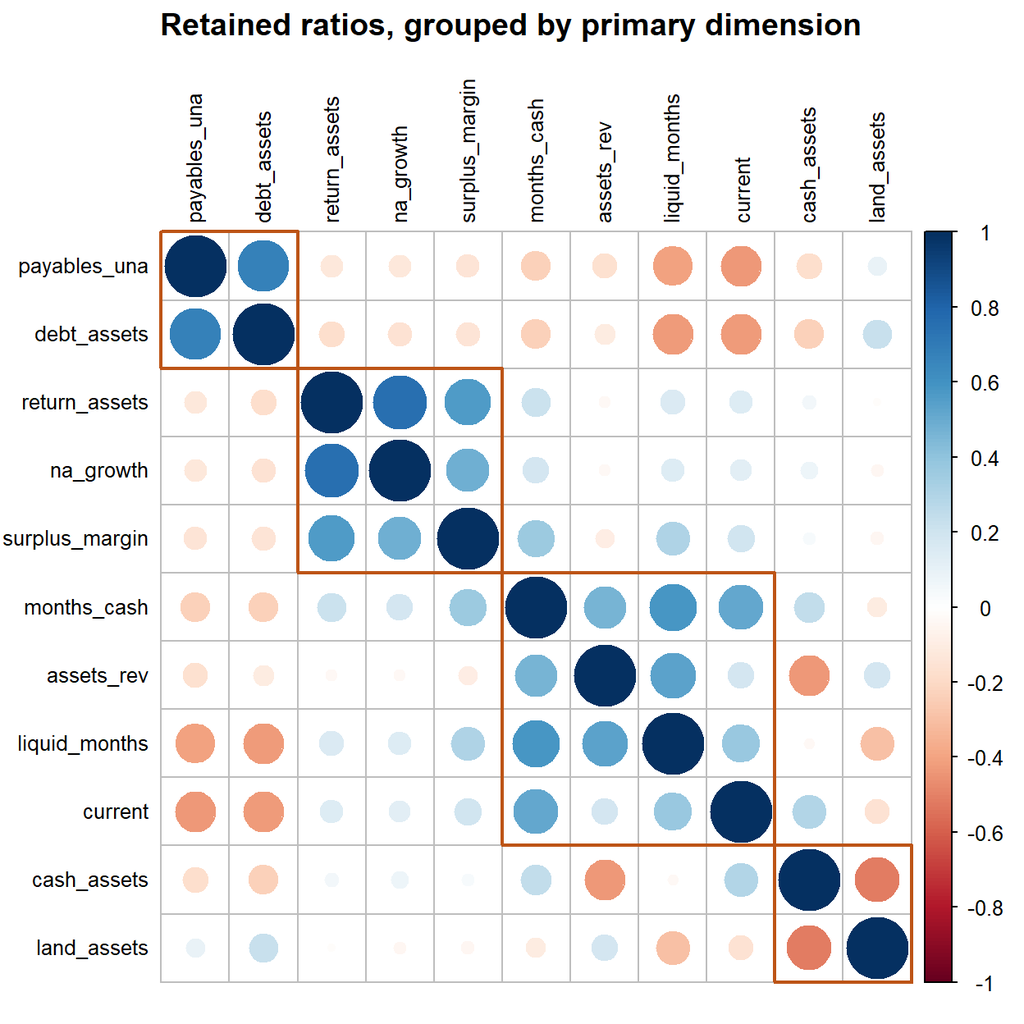

```r
ord <- names(sort(apply(abs(L_final), 1, which.max) * 10 - apply(abs(L_final), 1, max)))
C <- cor(X[ord])
res <- corrplot(C, order = "original", tl.col = "black", tl.cex = 0.8, mar = c(0, 0, 1.5, 0),
                title = "Retained ratios, grouped by primary dimension")
grp <- apply(abs(L_final[ord, ]), 1, which.max)
corrRect(res, index = c(which(!duplicated(grp)), length(grp)), col = "#bd5416", lwd = 2)
```

Each label names what the indicators have in common: their accounting source, what they respond to, and the question they answer. “Higher is healthier” is stated only where the direction is unambiguous.

#### Leverage (`debt_assets`, `payables_una`)

- **Source.** Balance-sheet claims. Debt-to-assets is the share of all assets financed by liabilities. The payables share is the share of short-term capital (payables plus unrestricted equity) that is owed to vendors and grantees.
- **Why separate from reserves.** The three-component solution merges them. In four, leverage stands on its own, correlates only modestly (negatively) with reserves, and reproduces across sizes and years. Organizations can hold large reserves *and* significant debt (property financed by mortgages), or neither.
- **Healthy direction.** Lower. High scores mean creditors, not the organization, have the claim on its resources.
- **Relation to the AA/NH/PI study.** This corresponds to *leverage*. Unlike the study, debt-to-assets belongs here and not in a separate solvency dimension. Once negative net assets are handled, debt-to-equity-style ratios and debt-to-assets measure one construct.

#### Operating performance (`surplus_margin`, `return_assets`, `na_growth`)

- **Source.** Income-statement flows and their result: this year’s surplus relative to revenue and assets, and the resulting change in net assets.
- **Healthy direction.** Higher, within reason. A single deficit year is not distress.
- **Relation to the AA/NH/PI study.** *Growth potential.* That dimension also included asset and revenue growth. Section 6 adds those and finds that they join this dimension.

#### Liquidity and reserves (`months_cash`, `liquid_months`, `assets_rev`, `current`)

- **Source.** Stocks of liquid and unrestricted resources measured against spending: months of cash and receivables, months of liquid unrestricted net assets, assets per dollar of revenue, and current assets per dollar of current liabilities.
- **Why `assets_rev` loads here.** It measures the stock of resources relative to the flow of activity. Organizations with more assets per dollar of revenue carry larger reserves relative to operations. It also cross-loads on asset structure, because *what* those assets are (cash or buildings) matters too.
- **Why `current` is the weakest member.** Its denominator is a liability, so it loads almost equally (with opposite sign) on leverage. It is best treated as a secondary indicator of this dimension.
- **Healthy direction.** Higher, up to a point. The index doesn’t penalize hoarding.
- **Relation to the AA/NH/PI study.** The resilience half of *solvency*. The study’s solvency dimension mixed reserves, debt-to-assets, and asset mix.

#### Asset structure (`cash_assets` vs. `land_assets`)

- **Source.** Composition of the asset base: liquid (cash and savings) versus fixed (land, buildings, equipment).
- **Caveat.** Cash and property are shares of the same total, so part of their negative correlation is compositional. That is why the individual KMO values sit just below 0.50.
- **Healthy direction.** **None.** A capital-intensive organization (hospital, school, housing provider) isn’t less healthy than a cash-based one; it has a different business model.
- **Recommendation.** Treat asset structure as a **context dimension**: a stratifier or control. Don’t add it to a directional health composite.
- **Relation to the AA/NH/PI study.** The asset-mix part of *solvency* and of *organizational slack* (land-to-assets and asset-to-revenue loaded on both).

#### Standalone measures (not dimensions)

- **Administrative share, fundraising share, self-sufficiency.** They share almost no variance with financial condition or with each other. Report them as descriptors of expense allocation and revenue model.
- **Organizational slack.** The study’s slack dimension paired the administrative-expense ratio with the program-efficiency ratio. Those two are complements by construction, so the pair forms a component regardless of how organizations behave. Without the complement, no slack dimension appears.

## 6. Adding revenue and asset growth

The AA/NH/PI study’s *growth potential* dimension combined one-year asset growth and one-year revenue growth with net profit and operating margins. This section tests whether growth measures join the performance dimension here too.

**Measurement model for growth.** A panel isn’t strictly needed. One 2023 return already reports both years:

- **Revenue:** Part I lists prior-year and current-year total revenue (`F9_01_REV_TOT_PY`, `F9_01_REV_TOT_CY`).
- **Assets:** Part X lists beginning- and end-of-year total assets (`F9_10_ASSET_TOT_BOY`, `F9_10_ASSET_TOT_EOY`).

Both use the same **symmetric growth rate** as net-asset growth: change ÷ mean(abs(new), abs(old)). It is bounded in [−2, 2], defined whenever either year is nonzero, and 0 when both are zero.

A blank prior-year revenue means *not reported* (for example, first-year filers), not zero. It is filled from the organization’s 2022 return where one exists; the rest are imputed conditionally, like every other undefined ratio.

```r
src <- ifelse(is.na(built$components$R_py_source), "imputed (no 2022 return)",
              built$components$R_py_source)
kable(data.frame(prior_year_revenue_source = names(table(src)),
                 share = round(as.numeric(prop.table(table(src))), 3)),
      row.names = FALSE)
```

| prior_year_revenue_source | share |
| --- | --- |
| imputed (no 2022 return) | 0.017 |
| prior-year return | 0.023 |
| return | 0.960 |

### 6.1 Single-return growth vs. panel growth

If a single return is a sound substitute for a panel, its prior-year figures should match what the organization reported on its 2022 return, and the growth rates should rank organizations the same way.

```r
prior <- prior[!duplicated(prior$EIN2), ]
m <- match(built$ein, prior$EIN2)
k <- built$components
R22 <- suppressWarnings(as.numeric(fix64(prior$F9_01_REV_TOT_CY)))[m]
A22 <- suppressWarnings(as.numeric(fix64(prior$F9_10_ASSET_TOT_EOY)))[m]
A22_ez <- suppressWarnings(as.numeric(fix64(prior$F9_01_NAFB_ASSET_TOT_EOY)))[m]
swap <- (is.na(A22) | A22 == 0) & !is.na(A22_ez)
A22[swap] <- A22_ez[swap]

panel_rev_growth   <- ifelse(is.na(R22), NA, sym_growth(k$R_cy, R22))
panel_asset_growth <- ifelse(is.na(A22), NA, sym_growth(k$A, A22))
ok_rev   <- !is.na(panel_rev_growth) & k$R_py_source %in% "return"
ok_asset <- !is.na(panel_asset_growth)
within_1pct <- function(a, b) mean(abs(a - b) <= 0.01 * pmax(abs(b), 1))

kable(data.frame(
  check = c("2023 filers matched to a 2022 return",
            "Prior-year revenue within 1% of 2022 current-year revenue",
            "Spearman rho: revenue growth, single return vs. panel",
            "Beginning-of-year assets within 1% of 2022 end-of-year assets",
            "Spearman rho: asset growth, single return vs. panel"),
  value = c(mean(!is.na(m)),
            within_1pct(k$R_py[ok_rev], R22[ok_rev]),
            cor(frame$rev_growth[ok_rev], panel_rev_growth[ok_rev], method = "spearman"),
            within_1pct(k$A_boy[ok_asset], A22[ok_asset]),
            cor(frame$asset_growth[ok_asset], panel_asset_growth[ok_asset], method = "spearman"))),
  digits = 3, row.names = FALSE)
```

| check | value |
| --- | --- |
| 2023 filers matched to a 2022 return | 0.966 |
| Prior-year revenue within 1% of 2022 current-year revenue | 0.984 |
| Spearman rho: revenue growth, single return vs. panel | 0.989 |
| Beginning-of-year assets within 1% of 2022 end-of-year assets | 0.979 |
| Spearman rho: asset growth, single return vs. panel | 0.985 |

> **Decision E: Measure growth within the 2023 return, filling blanks from the 2022 return.**

> *Why:* The single-return figures agree with the panel almost exactly. The small differences likely reflect amended figures and changed fiscal years. Using the return itself covers every filer, including organizations without a matched 2022 e-filing, while the panel covers only 97%. Section 6.3 confirms the dimensions are the same either way.

### 6.2 Where growth loads

```r
retained_g <- c(retained, growth_vars)
Xg <- as.data.frame(lapply(frame[retained_g], winsor_normalize))
Rg <- cor(Xg)
diag_g <- fiscal_diagnostics(Xg)
kable(diag_g$variables[diag_g$variables$variable %in% c(growth_vars, "na_growth",
                                                         "surplus_margin", "return_assets"),
                       c("variable", "kmo_msa", "communality", "max_abs_cor", "redundant_with")],
      digits = 3, row.names = FALSE)
```

| variable | kmo_msa | communality | max_abs_cor | redundant_with |
| --- | --- | --- | --- | --- |
| surplus_margin | 0.657 | 0.439 | 0.569 |  |
| return_assets | 0.830 | 0.747 | 0.752 |  |
| na_growth | 0.803 | 0.714 | 0.766 |  |
| rev_growth | 0.843 | 0.213 | 0.425 |  |
| asset_growth | 0.803 | 0.691 | 0.766 |  |

```r
kable(round(Rg[growth_vars, ], 2), caption = "Correlations of growth with the retained ratios")
```

Correlations of growth with the retained ratios

|  | current | months_cash | liquid_months | cash_assets | debt_assets | payables_una | surplus_margin | return_assets | na_growth | land_assets | assets_rev | rev_growth | asset_growth |
| --- | --- | --- | --- | --- | --- | --- | --- | --- | --- | --- | --- | --- | --- |
| rev_growth | 0.03 | 0.03 | 0.03 | 0.04 | -0.02 | -0.01 | 0.43 | 0.34 | 0.33 | -0.04 | -0.16 | 1.00 | 0.36 |
| asset_growth | 0.11 | 0.19 | 0.12 | 0.08 | -0.05 | -0.04 | 0.46 | 0.72 | 0.77 | -0.04 | -0.03 | 0.36 | 1.00 |

```r
invisible(capture.output(
  pa_g <- fa.parallel(Rg, n.obs = nrow(Xg), fa = "both", plot = FALSE, n.iter = 50)))
c(parallel_pca = pa_g$ncomp, parallel_fa = pa_g$nfact)
```

```
## parallel_pca  parallel_fa
##            4            5
```

```r
show_solution_g <- function(k) {
  L <- unclass(principal(Rg, nfactors = k, rotate = "oblimin", n.obs = nrow(Xg))$loadings)
  L[abs(L) < 0.30] <- NA
  colnames(L) <- paste0("k", k, "_C", seq_len(k))
  L
}
kable(do.call(cbind, lapply(4:5, show_solution_g)), digits = 2,
      caption = "PCA (oblimin) with growth measures added")
```

PCA (oblimin) with growth measures added

|  | k4_C1 | k4_C2 | k4_C3 | k4_C4 | k5_C1 | k5_C2 | k5_C3 | k5_C4 | k5_C5 |
| --- | --- | --- | --- | --- | --- | --- | --- | --- | --- |
| current |  | 0.41 | -0.40 |  |  | 0.40 | -0.39 |  |  |
| months_cash |  | 0.85 |  |  |  | 0.86 |  |  |  |
| liquid_months |  | 0.76 |  |  |  | 0.77 |  |  |  |
| cash_assets |  |  |  | 0.88 |  |  |  | 0.90 |  |
| debt_assets |  |  | 0.88 |  |  |  | 0.89 |  |  |
| payables_una |  |  | 0.92 |  |  |  | 0.93 |  |  |
| surplus_margin | 0.71 |  |  |  | 0.35 |  |  |  | 0.57 |
| return_assets | 0.88 |  |  |  | 0.87 |  |  |  |  |
| na_growth | 0.87 |  |  |  | 0.92 |  |  |  |  |
| land_assets |  |  |  | -0.80 |  |  |  | -0.79 |  |
| assets_rev |  | 0.77 |  | -0.47 |  | 0.76 |  | -0.47 |  |
| rev_growth | 0.59 |  |  |  |  |  |  |  | 0.89 |
| asset_growth | 0.87 |  |  |  | 0.90 |  |  |  |  |

```r
efa_g <- fa(Rg, nfactors = 4, rotate = "oblimin", fm = "minres", n.obs = nrow(Xg))
L_efa_g <- unclass(efa_g$loadings); L_efa_g[abs(L_efa_g) < 0.30] <- NA
kable(L_efa_g, digits = 2, caption = "EFA (minres, oblimin), 4 factors, with growth measures")
```

EFA (minres, oblimin), 4 factors, with growth measures

|  | MR1 | MR2 | MR4 | MR3 |
| --- | --- | --- | --- | --- |
| current |  | 0.37 | -0.33 |  |
| months_cash |  | 0.89 |  |  |
| liquid_months |  | 0.59 | -0.32 |  |
| cash_assets |  |  |  | 0.98 |
| debt_assets |  |  | 0.87 |  |
| payables_una |  |  | 0.78 |  |
| surplus_margin | 0.61 |  |  |  |
| return_assets | 0.86 |  |  |  |
| na_growth | 0.85 |  |  |  |
| land_assets |  |  |  | -0.47 |
| assets_rev |  | 0.65 |  | -0.50 |
| rev_growth | 0.46 |  |  |  |
| asset_growth | 0.84 |  |  |  |

### 6.3 Stability of the growth-augmented solution

```r
loadings_g <- function(df) {
  unclass(principal(df[retained_g], nfactors = 4, rotate = "oblimin")$loadings)
}
Lg_ref <- loadings_g(Xg)

both_panel <- ok_asset & !is.na(panel_rev_growth)
frame_panel <- frame[both_panel, retained_g]
frame_panel$rev_growth   <- panel_rev_growth[both_panel]
frame_panel$asset_growth <- panel_asset_growth[both_panel]
Xg_panel  <- as.data.frame(lapply(frame_panel, winsor_normalize))
Xg_single <- Xg[both_panel, ]
Xg_rank   <- as.data.frame(lapply(frame[retained_g], rank_normal))
half_g    <- sample(nrow(Xg), nrow(Xg) / 2)

growth_checks <- list(
  `Random half A vs. half B`               = list(Xg[half_g, ], Xg[-half_g, ]),
  `Expenses < $500k vs. full sample`       = list(Xg[exp_total < 5e5, ], NULL),
  `$500k-$5M vs. full sample`              = list(Xg[exp_total >= 5e5 & exp_total < 5e6, ], NULL),
  `>= $5M vs. full sample`                 = list(Xg[exp_total >= 5e6, ], NULL),
  `Rank-normal vs. winsorized+normalized`  = list(Xg_rank, NULL),
  `Panel growth vs. single-return growth (matched filers)` = list(Xg_panel, Xg_single))

growth_stab <- do.call(rbind, lapply(names(growth_checks), function(nm) {
  A <- loadings_g(growth_checks[[nm]][[1]])
  B <- if (is.null(growth_checks[[nm]][[2]])) Lg_ref else loadings_g(growth_checks[[nm]][[2]])
  cg <- congruence(B, A)
  data.frame(comparison = nm, n = format(nrow(growth_checks[[nm]][[1]]), big.mark = ","),
             t(setNames(sprintf("%.2f", cg), names(cg))), check.names = FALSE)
}))
kable(growth_stab, row.names = FALSE, format.args = list(big.mark = ","))
```

| comparison | n | performance | reserves | leverage | asset_structure |
| --- | --- | --- | --- | --- | --- |
| Random half A vs. half B | 160,806 | 1.00 | 1.00 | 1.00 | 1.00 |
| Expenses < $500k vs. full sample | 171,273 | 1.00 | 1.00 | 0.99 | 1.00 |
| $500k-$5M vs. full sample | 111,728 | 1.00 | 0.99 | 0.99 | 1.00 |
| >= $5M vs. full sample | 38,611 | 1.00 | 0.95 | 0.97 | 0.97 |
| Rank-normal vs. winsorized+normalized | 321,612 | 1.00 | 0.99 | 0.98 | 0.99 |
| Panel growth vs. single-return growth (matched filers) | 310,538 | 1.00 | 1.00 | 1.00 | 1.00 |

```r
Lg_final <- label_components(Lg_ref)[, c("leverage", "performance", "reserves", "asset_structure")]
kable(Lg_final, digits = 2, caption = "Four-component oblimin loadings with growth measures, all 2023 filers")
```

Four-component oblimin loadings with growth measures, all 2023 filers

|  | leverage | performance | reserves | asset_structure |
| --- | --- | --- | --- | --- |
| current | -0.40 | 0.03 | 0.41 | 0.27 |
| months_cash | 0.07 | 0.14 | 0.85 | 0.24 |
| liquid_months | -0.22 | 0.06 | 0.76 | 0.05 |
| cash_assets | -0.09 | -0.02 | -0.08 | 0.88 |
| debt_assets | 0.88 | -0.01 | 0.00 | -0.07 |
| payables_una | 0.92 | 0.00 | 0.01 | 0.06 |
| surplus_margin | 0.01 | 0.71 | 0.18 | 0.06 |
| return_assets | -0.06 | 0.88 | -0.01 | -0.07 |
| na_growth | -0.05 | 0.87 | -0.03 | -0.05 |
| land_assets | -0.04 | 0.08 | -0.16 | -0.80 |
| assets_rev | -0.02 | -0.14 | 0.77 | -0.47 |
| rev_growth | 0.05 | 0.59 | -0.14 | 0.04 |
| asset_growth | 0.08 | 0.87 | 0.02 | -0.02 |

```r
kable(cbind(without_growth = L_final[retained, "performance"],
            with_growth    = Lg_final[retained, "performance"]), digits = 2,
      caption = "Performance loadings of the original ratios, before and after adding growth")
```

Performance loadings of the original ratios, before and after adding growth

|  | without_growth | with_growth |
| --- | --- | --- |
| current | 0.03 | 0.03 |
| months_cash | 0.17 | 0.14 |
| liquid_months | 0.06 | 0.06 |
| cash_assets | -0.02 | -0.02 |
| debt_assets | -0.02 | -0.01 |
| payables_una | 0.00 | 0.00 |
| surplus_margin | 0.77 | 0.71 |
| return_assets | 0.91 | 0.88 |
| na_growth | 0.88 | 0.87 |
| land_assets | 0.10 | 0.08 |
| assets_rev | -0.16 | -0.14 |

**What the growth test shows.**

> **Decision F: Add revenue growth and asset growth to the performance dimension, and relabel it *Performance & growth*.**

> The structure is stable across random halves, organization size, and transformation. It is also identical whether growth comes from the single return or from the 2022–2023 panel.

## 7. Comparison with earlier results

|  | AA/NH/PI study | `fiscal-health-index-2023` | This analysis |
| --- | --- | --- | --- |
| Ratios entering discovery | 13 | 5 | 11 |
| Negative denominators | kept (sign flips) | excluded ratios | bounded reformulation |
| Undefined cases | dropped | excluded ratios | rules + conditional imputation |
| Transformation | winsorize 5/95, log, z | rank-normal | winsorize 1/99, asinh, z |
| Dimensions | 4 | 2 | 4 (3 directional + 1 context) |
| Performance / growth | yes (growth potential) | yes (margins only) | yes (margins, net-asset, asset, and revenue growth) |
| Leverage | yes | merged into reserves | yes |
| Reserves / solvency | yes (mixed with asset mix) | yes (with debt) | yes (liquidity & reserves) |
| Slack | yes | — | no (closure artifact) |
| Asset structure | inside solvency and slack | excluded | yes (context) |

The two-dimension result came from excluding leverage and asset-structure ratios at the screening stage. The leverage ratios were excluded because their denominators can be negative; the bounded reformulation fixes that. The asset-structure ratios were excluded because their healthy direction is ambiguous, which is still true. That is why asset structure is kept as a context dimension rather than part of the health composite.

## 8. Next steps

- **Fit the measurement model** with `fiscal_health_fit()`. Use the three directional dimensions:

  | Dimension | Direction |
  | --- | --- |
  | leverage | lower is better |
  | performance & growth (including `rev_growth`, `asset_growth`) | higher |
  | reserves | higher |

  Keep `asset_structure` and the three standalone measures as reported, non-weighted columns.
- **Package support.** Port the rules and conditional imputation in `build-ratio-frame.R` into package functions, so the `_z` columns match the measurement model used here. This includes fixing the zero-MAD failure for zero-inflated shares.
- **Multi-year stability.** Repeat the discovery for 2022 and earlier years, now that growth can be measured within a single return. Check whether the five-component split (revenue growth with margin, separate from balance-sheet growth) recurs.